# DESARROLLO Y EVALUACIÓN DEL MODELO

```python
import warnings
warnings.filterwarnings('ignore')
```

```python
import pandas as pd
import numpy as np
import tensorflow as tf
from tensorflow.keras.models import Model
from tensorflow.keras.layers import Input, LSTM, Dense, Dropout, BatchNormalization, Attention, Bidirectional
from tensorflow.keras.callbacks import EarlyStopping
from sklearn.model_selection import TimeSeriesSplit, cross_val_score
from sklearn.metrics import mean_squared_error, r2_score, mean_absolute_error
from sklearn.preprocessing import StandardScaler
from sklearn.linear_model import LinearRegression
from sklearn.ensemble import RandomForestRegressor
import xgboost as xgb
from statsmodels.tsa.arima.model import ARIMA
from pmdarima import auto_arima
from sklearn.svm import SVR
import matplotlib.pyplot as plt
import scipy.stats as stats
```

```python
## FUNCIONES ##

# Cálculo del R2 ajustado
def adjusted_r2(_r2, _n, _p):
    return 1 - ((1 - _r2) * (_n - 1) / (_n - _p - 1))

# Devuelve un valor desnormalizado; emplear cuando el modelo haya dado una predicción de precio para conocer el valor en USDT
def denormalize_data(_data, _df, _var='close', _window=20, _index=None):     # Usar _df = df_close
    if _index is None:
        _index = len(_df) - 1

    serie = _df[_var]

    # Calcular la media y desviación estándar de la ventana en el índice de predicción
    if _index >= _window - 1:  # Si el índice tiene suficientes datos para la ventana completa
        ventana = serie.iloc[_index - _window + 1 : _index + 1]
    else:  # Si el índice está en el rango inicial y usa una ventana reducida
        ventana = serie.iloc[: _index + 1]

    mean_window = ventana.mean()
    std_window = ventana.std(ddof=0)

    # Desnormalizar el valor
    if std_window > 0:  # Evitar división por cero
        return round((_data * std_window) + mean_window, 2)
    else:
        return round(mean_window, 2)  # Si la desviación es 0, el valor normalizado corresponde a la media
```

```python
## MODELOS ##

# Creación de la red neuronal recurrente
def recurrent_neural_network(_params, _X):
    inputs = Input(shape=(_X.shape[1], _X.shape[2]))
    x = inputs

    # Capas LSTM bidireccionales con Dropout
    for _ in range(_params["n_lstm_layers"]):
        x = Bidirectional(
            LSTM(_params["n_lstm_units"], return_sequences=True, kernel_regularizer=tf.keras.regularizers.l2(0.01))
        )(x)
        x = Dropout(_params["dropout_rate"])(x)
        x = BatchNormalization()(x)

    # Capa de atención
    attention_output = Attention()([x, x])
    x = tf.keras.layers.Concatenate()([x, attention_output])

    # Capas densas
    for _ in range(_params["n_dense_layers"]):
        x = Dense(_params["n_dense_units"], activation="relu")(x)
        x = Dropout(_params["dropout_rate"])(x)

    # Salida
    outputs = Dense(1, activation="linear")(x)
    model = Model(inputs, outputs)
    model.compile(optimizer=tf.keras.optimizers.Adam(learning_rate=_params["learning_rate"]),
                  loss="mse")
    return model

# Entrenamiento de la red neuronal recurrente
def recurrent_neural_network_training(_X_train, _y_train, _params, _early_stopping, _n_splits=5):
    # Empleo de TimeSeriesSplit para realizar la validación cruzada en series temporales
    tscv = TimeSeriesSplit(_n_splits)
    fold = 1
    all_val_losses = []
    r2_scores = []

    # Iteración sobre los folds
    for train_idx, val_idx in tscv.split(_X_train):
        print(f"Fold: {fold} - INICIO")
        # División de los datos
        X_train, X_val = _X_train[train_idx], _X_train[val_idx]
        y_train, y_val = _y_train[train_idx], _y_train[val_idx]

        # Construcción del modelo
        model = recurrent_neural_network(_params, _X_train)

        # Early stopping para la detención temprana si no hay mejora en la pérdida de validación tras 5 épocas consecutivas
        early_stopping = _early_stopping

        # Entrenamiento del modelo
        model.fit(
            X_train, y_train,
            validation_data=(X_val, y_val),
            epochs=_params["epochs"],
            batch_size=_params["batch_size"],
            callbacks=[early_stopping],
            verbose=1
        )

        val_loss = model.evaluate(X_val, y_val, verbose=0)
        all_val_losses.append(val_loss)
        print(f"Fold {fold} - Pérdida de validación: {round(val_loss,4)}")

        # Cálculo de R2 en el conjunto de validación
        y_val_pred = model.predict(X_val)
        y_val_pred = y_val_pred[:, -1, 0]

        y_val_pred_denorm = []
        y_val_true = []
        denorm_index = val_idx[0]  # Ajustar índice base según ventana y entrenamiento

        # Desnormalización de cada predicción
        for i, pred in enumerate(y_val_pred):
            denorm = denormalize_data(_data=pred, _df=df_close, _index=denorm_index + i)
            y_val_pred_denorm.append(denorm)
            y_val_true.append(df_close.close.tolist()[denorm_index + i])

        r2 = r2_score(y_val_true, y_val_pred_denorm)
        r2_scores.append(r2)
        print(f"Fold: {fold} - R2: {round(r2, 4)}")

        fold += 1

    mean_val_loss = np.mean(all_val_losses)
    print(f"Pérdida media de validación en todos los folds: {round(mean_val_loss,4)}")

    return model, r2_scores


# Modelo de regresión lineal
def linear_regression(_X_train, _y_train, _n_splits=5):
    tscv = TimeSeriesSplit(_n_splits)
    fold = 1
    r2_scores = []

    for train_idx, val_idx in tscv.split(_X_train):
        print(f"Fold: {fold} - INICIO")
        X_train, X_val = _X_train[train_idx], _X_train[val_idx]
        y_train, y_val = _y_train[train_idx], _y_train[val_idx]

        model = LinearRegression()
        model.fit(X_train, y_train)

        y_val_pred = model.predict(X_val)

        y_val_pred_denorm = []
        y_val_true = []
        denorm_index = val_idx[0]

        for i, pred in enumerate(y_val_pred):
            denorm = denormalize_data(_data=pred, _df=df_close, _index=denorm_index + i)
            y_val_pred_denorm.append(denorm)
            y_val_true.append(df_close.close.tolist()[denorm_index + i])

        r2 = r2_score(y_val_true, y_val_pred_denorm)
        r2_scores.append(r2)
        print(f"Fold: {fold} - R2: {round(r2, 4)}")

        fold += 1

    return model, r2_scores


# Modelo Random Forest
def random_forest(_X_train, _y_train, _params, _n_splits=5):
    # Aplanar las ventanas para Random Forest
    X_train_flat = _X_train.reshape(_X_train.shape[0], -1)

    # Configuración del modelo Random Forest
    model = RandomForestRegressor(
        n_estimators=_params["n_estimators"],
        max_depth=_params["max_depth"],
        random_state=_params["random_state"],
        n_jobs=_params["n_jobs"]
    )

    tscv = TimeSeriesSplit(n_splits=5)
    fold = 1
    r2_scores = []

    for train_idx, val_idx in tscv.split(X_train_flat):
        print(f"Fold: {fold} - INICIO")
        X_train_fold, X_val_fold = X_train_flat[train_idx], X_train_flat[val_idx]
        y_train_fold, y_val_fold = y_train[train_idx], y_train[val_idx]

        # Entrenar el modelo
        model.fit(X_train_fold, y_train_fold)

        # Predicciones en el conjunto de validación
        y_val_pred = model.predict(X_val_fold)

        y_val_pred_denorm = []
        y_val_true = []
        denorm_index = val_idx[0]

        for i, pred in enumerate(y_val_pred):
            denorm = denormalize_data(_data=pred, _df=df_close, _index=denorm_index + i)
            y_val_pred_denorm.append(denorm)
            y_val_true.append(df_close.close.tolist()[denorm_index + i])

        r2 = r2_score(y_val_true, y_val_pred_denorm)
        r2_scores.append(r2)
        print(f"Fold: {fold} - R2: {round(r2, 4)}")

        fold += 1

    return model, r2_scores


# Modelo XGBoost
def xgboost(_X_train, _y_train, _params, _n_splits=5):
    # Aplanar las ventanas para XGBoost
    X_train_flat = _X_train.reshape(_X_train.shape[0], -1)

    # Configuración del modelo XGBoost
    model = xgb.XGBRegressor(
        n_estimators=_params["n_estimators"],
        learning_rate=_params["learning_rate"],
        max_depth=_params["max_depth"],
        subsample=_params["subsample"],
        colsample_bytree=_params["colsample_bytree"],
        random_state=_params["random_state"]
    )

    tscv = TimeSeriesSplit(n_splits=5)
    fold = 1
    r2_scores = []

    for train_idx, val_idx in tscv.split(X_train_flat):
        print(f"Fold: {fold} - INICIO")
        X_train_fold, X_val_fold = X_train_flat[train_idx], X_train_flat[val_idx]
        y_train_fold, y_val_fold = y_train[train_idx], y_train[val_idx]

        # Entrenar el modelo
        model.fit(X_train_fold, y_train_fold)

        # Predicciones en el conjunto de validación
        y_val_pred = model.predict(X_val_fold)

        y_val_pred_denorm = []
        y_val_true = []
        denorm_index = val_idx[0]

        for i, pred in enumerate(y_val_pred):
            denorm = denormalize_data(_data=pred, _df=df_close, _index=denorm_index + i)
            y_val_pred_denorm.append(denorm)
            y_val_true.append(df_close.close.tolist()[denorm_index + i])

        r2 = r2_score(y_val_true, y_val_pred_denorm)
        r2_scores.append(r2)
        print(f"Fold: {fold} - R2: {round(r2, 4)}")

        fold += 1

    return model, r2_scores


# Modelo ARIMA
def arima(_y_train, _params, _n_splits=5):
    tscv = TimeSeriesSplit(_n_splits)
    fold = 1
    r2_scores = []

    for train_idx, val_idx in tscv.split(_y_train):
        print(f"Fold: {fold} - INICIO")
        y_train, y_val = _y_train[train_idx], _y_train[val_idx]

        model = ARIMA(y_train, order=(_params["p"], _params["d"], _params["q"]))
        model_fitted = model.fit()

        _start = len(y_train)
        _end = len(y_train) + len(y_val) - 1

        y_val_pred = model_fitted.predict(start=_start, end=_end)

        r2 = r2_score(y_val, y_val_pred)
        r2_scores.append(r2)
        print(f"Fold: {fold} - R2: {round(r2, 4)}")

        fold += 1

    return model_fitted, r2_scores


# Modelo Support Vector Regressor
def svr(_X_train, _y_train, _params, _n_splits=5):
    tscv = TimeSeriesSplit(n_splits=_n_splits)
    fold = 1
    r2_scores = []

    X_train_flat = _X_train.reshape(_X_train.shape[0], -1)

    model = SVR(
        kernel=_params["kernel"],
        C=_params["C"],
        epsilon=_params["epsilon"]
    )

    for train_idx, val_idx in tscv.split(X_train_flat):
        print(f"Fold: {fold} - INICIO")
        X_train_fold, X_val_fold = X_train_flat[train_idx], X_train_flat[val_idx]
        y_train_fold, y_val_fold = _y_train[train_idx], _y_train[val_idx]

        model.fit(X_train_fold, y_train_fold)

        y_val_pred = model.predict(X_val_fold)

        y_val_pred_denorm = []
        y_val_true = []
        denorm_index = val_idx[0]

        for i, pred in enumerate(y_val_pred):
            denorm = denormalize_data(_data=pred, _df=df_close, _index=denorm_index + i)
            y_val_pred_denorm.append(denorm)
            y_val_true.append(df_close.close.tolist()[denorm_index + i])

        r2 = r2_score(y_val_true, y_val_pred_denorm)
        r2_scores.append(r2)
        print(f"Fold: {fold} - R2: {round(r2, 4)}")

        fold += 1

    return model, r2_scores
```

```python
## GRÁFICOS ##

# Representa un gráfico comparando cada predicción con su residuo
def residuals_vs_predictions(_pred, _resid):
    plt.figure(figsize=(14, 6))

    plt.scatter(_pred, _resid, color='orange', alpha=0.6)
    plt.axhline(0, color='black', linestyle='--')
    plt.title("Residuos vs Predicciones")
    plt.xlabel("Predicciones")
    plt.ylabel("Residuos")


# Representa un gráfico comparando los valores de test con los valores predichos por el modelo
def test_vs_estimacion(_y_test, _y_pred):
    fig, ax = plt.subplots(figsize=(12,8))
    plt.scatter(_y_test, _y_pred,  color='royalblue')
    plt.plot(_y_test, _y_test, color='black', linewidth=3)

    plt.xlabel("Test")
    plt.ylabel("Estimación")
    plt.show()


# Representa un histograma de distribución de residuos
def residual_histogram(_residuals, _bins=20):
    plt.figure(figsize=(14, 6))

    plt.hist(_residuals, bins=_bins, color='orange', alpha=1)

    # Media de la distribución
    mean_residual = np.mean(_residuals)
    plt.axvline(mean_residual, color='red', linestyle='dashed', linewidth=2, label=f'Media: {mean_residual:.2f}')

    plt.title("Histograma de Residuos")
    plt.xlabel("Residuos")

    plt.tight_layout()
    plt.legend()
    plt.show()


# Representa un gráfico QQPlot para comparar la normalidad de los residuos
def residuals_qqplot(_residuals):
    plt.figure(figsize=(14, 6))

    stats.probplot(_residuals, dist="norm", plot=plt)
    plt.title("QQPlot de Residuos")

    plt.tight_layout()
    plt.show()
```

```python
## FICHEROS ##

# Guardar y recuperar datos csv.
def save_csv(_df, _coin1, _coin2, _date=False):
    pair = _coin1 + _coin2
    if(_date):
        date = _df.date[0].strftime('%Y%m%d')
        _df.to_csv(f'archivos/{pair}_{date}.csv', index=False)
    else:
        _df.to_csv(f'archivos/{pair}.csv', index=False)

def open_csv(_file):
    return pd.read_csv(f'archivos/{_file}')


def open_json_file(_file):
    with open(f'archivos/{_file}', 'r', encoding='utf-8') as file:
        return json.load(file)
```

### 4. Desarrollo del modelo

La idea principal de este proyecto es entrenar una red neuronal recurrente que sea capaz de predecir el precio de Bitcoin en base a las variables contenidas en el set de datos que se ha obtenido en la fase anterior. Además, una vez entrenado y testeado, se entrenarán diferentes modelos más simples para comparar resultados, así como diferentes redes neuronales con combinaciones de variables distintas.

En principio, aunque se planteó la opción de emplear servicios en la nube para realizar la fase de entrenamiento del modelo, debido al número no muy elevado de datos que se disponen se decide emplear los medios propios y acudir a los servicios en la nube sólo en caso necesario.

En primer lugar, se cargarán los datos necesarios para el entrenamiento y la desnormalización de los precios predichos por el modelo.

```python
# Dataframe con los precios de cierre de Bitcoin; se emplearán en la desnormalización
df_close = open_csv("dfclose.csv")

# Dataframe de datos normalizados
df_norm = open_csv("dfready.csv")
df_norm
```

|  | date | close | VOL_BTC | VOL_USDT | transactions | total_supply | fed_funds_rate | sp500 | eur_usd | gbp_usd | jpy_usd | range | delta_open_close | percent_variation | percent_buy_market | sma_7 | macd | historical_volatility | bollinger_mean |
| --- | --- | --- | --- | --- | --- | --- | --- | --- | --- | --- | --- | --- | --- | --- | --- | --- | --- | --- | --- |
| 0 | 2017-09-25 | -0.085401 | -0.560892 | -0.699981 | 1.261409 | -2.082601 | -0.559575 | 0.350046 | -0.592119 | 0.824893 | -1.274712 | 1.144172 | -1.577317 | 1.589879 | -0.755249 | -0.949703 | -0.641271 | 0.795666 | -1.846998 |
| 1 | 2017-09-26 | -0.099713 | -1.063747 | -1.215896 | 0.447806 | -2.080645 | -0.559575 | 0.284031 | -1.957006 | 0.592814 | -0.768540 | -1.602020 | 0.266043 | -0.277257 | -0.444980 | -0.878831 | -0.397677 | 0.623934 | -1.794520 |
| 2 | 2017-09-27 | 1.122924 | -0.814737 | -0.818137 | 0.556466 | -2.078689 | -0.559575 | 0.860033 | -2.620322 | 0.344516 | -1.046032 | 1.299942 | -1.331452 | 1.283955 | 1.242939 | -0.654669 | 0.168071 | 0.705831 | -1.695572 |
| 3 | 2017-09-28 | 1.102849 | -0.152215 | 0.091193 | 1.820999 | -2.076600 | -0.559575 | 1.025069 | -2.568349 | -0.052404 | -1.236413 | -0.561697 | 0.645138 | -0.645081 | -0.483257 | -0.259479 | 0.715206 | 0.429499 | -1.530909 |
| 4 | 2017-09-29 | 1.142915 | 1.723521 | 2.239944 | 2.727527 | -2.074512 | -0.610893 | 1.800645 | -1.846679 | 0.064926 | -0.909286 | 0.671190 | 0.550353 | -0.559231 | -0.690897 | 0.201619 | 1.241301 | 0.348591 | -1.394947 |
| ... | ... | ... | ... | ... | ... | ... | ... | ... | ... | ... | ... | ... | ... | ... | ... | ... | ... | ... | ... |
| 2615 | 2024-11-22 | 1.503209 | -0.189959 | 0.107295 | 0.137776 | 1.381010 | 1.195509 | 0.643943 | -1.478081 | -1.484743 | -0.194169 | -0.718971 | 0.360430 | -0.379454 | -0.735712 | 1.485522 | 1.338367 | 0.543889 | 1.933734 |
| 2616 | 2024-11-23 | 1.265800 | -1.054117 | -0.908510 | -1.245873 | 1.381595 | 1.195509 | 0.575544 | -1.321903 | -1.311802 | -0.106426 | -1.485190 | 1.350555 | -1.327074 | -2.729985 | 1.436747 | 1.226510 | 0.497017 | 1.908522 |
| 2617 | 2024-11-24 | 1.213637 | -0.798832 | -0.661910 | -0.780186 | 1.382181 | 1.195509 | 0.532303 | -1.190516 | -1.167351 | -0.014875 | -0.359405 | 0.599217 | -0.622036 | -0.801017 | 1.414607 | 1.107554 | 0.288867 | 1.889185 |
| 2618 | 2024-11-25 | 0.572709 | -0.040178 | 0.170503 | 0.487972 | 1.382766 | 1.195509 | 0.854844 | -1.080196 | -1.041109 | 0.087710 | 1.875818 | 1.997675 | -1.981597 | -1.777760 | 1.329796 | 0.773773 | 1.167842 | 1.827903 |
| 2619 | 2024-11-26 | 0.354215 | 0.391267 | 0.499192 | 1.196128 | 1.382766 | 1.195509 | 1.447457 | -1.366222 | -1.356228 | 0.019515 | 0.344444 | 0.384151 | -0.409982 | 0.357434 | 1.220564 | 0.381991 | -0.042660 | 1.731872 |

2620 rows × 19 columns

Se eliminará la variable de tiempo ya que no es necesario para el entrenamiento del modelo.

```python
df_norm = df_norm.drop(columns=['date'], errors='ignore')
```

Se separan las características (X) de la variable objetivo (y) y se realiza la división de los sets para *train* y *test* (no se creará un set para validación ya que se empleará la validación cruzada durante el entrenamiento del modelo), empleando un 80% para *train* y el 20% para *test*.

```python
X = df_norm.drop(columns=['close']).values
y = df_norm['close'].values

# División en porcentajes para train y test
train_size = int(len(X) * 0.8)
test_size = len(X) - train_size

# Separación de los datos
X_train, y_train = X[:train_size], y[:train_size]
X_test, y_test = X[train_size:], y[train_size:]

print(f"Tamaños de los subsets: \n\tTrain = X: {len(X_train)}, y: {len(y_train)} \n\tTest = X: {len(X_test)}, y: {len(y_test)}")
```

```
Tamaños de los subsets:
	Train = X: 2096, y: 2096
	Test = X: 524, y: 524
```

#### 4.1. Red Neuronal Recurrente

La red neuronal seleccionada será una red neuronal recurrente diseñada para series temporales que emplea capas LSTM bidireccionales que buscan patrones temporales en ambas direcciones. También se emplearán los siguientes parámetros:

- _**n_lstm_units**_: número de neuronas en cada capa LSTM. Ayudan a capturar patrones complejos en datos secuenciales. Se establecerá en 128 por ser un valor comúnmente utilizado por su equilibrio entre el aprendizaje y el coste computacional.
- _**n_dense_units**_: número de neuronas en cada capa densa. Influye en cómo se combinan las características extraídas por las capas LSTM antes de generar una salida final. Se establece en 64 por ser un número que permite capturar suficientes relaciones sin aumentar el coste computacional.
- _**n_lstm_layers**_: número de capas LSTM en la red neuronal. Un mayor número de capas pueden capturar dependencias más profundas y complejas en datos secuenciales, pero un número excesivo de ellas puede provocar problemas de gradiente y aumentar el tiempo de entrenamiento.
- _**n_dense_layers**_: número de capas densas de la red neuronal. Un mayor número de capas permiten al modelo aprender combinaciones no lineales más complejas de las características, pero un número excesivo puede llevar a un problema de sobreajuste y aumentar el tiempo de entrenamiento.
- _**dropout_rate**_: porcentaje de neuronas que se desactivarán de manera aleatoria en cada capa. Ayuda a aumentar la robustez del modelo al reducir el posible sobreajuste. Una tasa del 30% es comúnmente utilizada y efectiva en redes moderadamente complejas.
- _**learning_rate**_: tasa de aprendizaje del optimizador. Controla el tamaño de los pasos que el optimizador da al actualizar los pesos del modelo, siendo que una tasa alta puede causar inestabilidad. Se empleará de inicio un valor estándar como es 0.001.

```python
params_rnn = {
    "n_lstm_units": 128,
    "n_dense_units": 64,
    "n_lstm_layers": 4,
    "n_dense_layers": 4,
    "dropout_rate": 0.3,
    "learning_rate": 0.001,
    "epochs": 50,
    "batch_size": 64,
}
```

Debido a que los dataframes de Pandas no son compatibles con las funciones de Keras, se procede a convertirlos en arrays.

```python
X_train_array = np.array(X_train)
y_train_array = np.array(y_train)
X_test_array = np.array(X_test)
y_test_array = np.array(y_test)
```

Debido a que el formato esperado por la red neuronal es de tres dimensiones (_n*samples*, _n*timesteps*, _n*features*), y los arrays obtenidos sólo tienen dos dimensiones, es necesario realizar una transformación empleando una ventana temporal para crear esta tercera dimensión.

```python
X_train_array.shape
```

```
(2096, 17)
```

```python
# Parámetro de la ventana temporal
window_size = 20

# Generación de ventanas deslizantes
# Para datos de train
X_windows = []
y_windows = []

for i in range(window_size, len(X_train_array)):
    X_windows.append(X_train_array[i-window_size:i])  # Ventana de features
    y_windows.append(y_train_array[i])  # Target correspondiente al último paso

X_train_array_shape = np.array(X_windows)  # Formato (n_samples, n_timesteps, n_features)
y_train_array_shape = np.array(y_windows)  # Formato (n_samples,)

# Para datos de test
X_test_windows = []
y_test_windows = []

for i in range(window_size, len(X_test_array)):
    X_test_windows.append(X_test_array[i-window_size:i])
    y_test_windows.append(y_test_array[i])

X_test_array_shape = np.array(X_test_windows)
y_test_array_shape = np.array(y_test_windows)
```

```python
X_train_array_shape.shape
```

```
(2076, 20, 17)
```

```python
X_test_array_shape.shape
```

```
(504, 20, 17)
```

Con los datos preparados se procede a crear y entrenar el modelo. Para ello, se empleará la librería TimeSeriesSplit que realiza una validación cruzada en series temporales, dividiendo los datos en *folds* y empleando siempre datos previos en el entrenamiento y datos posteriores en la validación, respetando el orden temporal y no barajando como en la validación cruzada tradicional. Se realizará el entrenamiento utilizando cinco *folds*.

```python
# Early stopping para la detención temprana si no hay mejora en la pérdida de validación tras 5 épocas consecutivas
early_stopping = EarlyStopping(monitor="val_loss", patience=5, restore_best_weights=True)

# Entrenamiento del modelo con 5 folds (por defecto)
model, r2_scores = recurrent_neural_network_training(X_train_array_shape, y_train_array_shape, params_rnn,
                                                     early_stopping)
```

```
Fold: 1 - INICIO
WARNING:tensorflow:From C:\Users\Usuario\AppData\Roaming\Python\Python310\site-packages\keras\src\backend.py:1398: The name tf.executing_eagerly_outside_functions is deprecated. Please use tf.compat.v1.executing_eagerly_outside_functions instead.

WARNING:tensorflow:From C:\Users\Usuario\AppData\Roaming\Python\Python310\site-packages\keras\src\utils\tf_utils.py:492: The name tf.ragged.RaggedTensorValue is deprecated. Please use tf.compat.v1.ragged.RaggedTensorValue instead.

Fold 1 - Pérdida de validación: 1.8645
Fold: 1 - R2: 0.9254
Fold: 2 - INICIO
Fold 2 - Pérdida de validación: 1.851
Fold: 2 - R2: 0.633
Fold: 3 - INICIO
Fold 3 - Pérdida de validación: 1.8341
Fold: 3 - R2: 0.945
Fold: 4 - INICIO
Fold 4 - Pérdida de validación: 1.8696
Fold: 4 - R2: 0.8436
Fold: 5 - INICIO
Fold 5 - Pérdida de validación: 1.8122
Fold: 5 - R2: 0.8447
Pérdida media de validación en todos los folds: 1.8463
```

Con el modelo entrenado se procede a su evaluación, en primer lugar observando la media de la pérdida de validación en todos los *folds*.

```python
mean_r2_scores = round(np.mean(r2_scores), 4)
print(f"R2 medio de los folds: {mean_r2_scores}")
```

```
R2 medio de los folds: 0.8384
```

Para calcular las métricas de evaluación se realizan predicciones empleando para ello el dataset de *test*.

```python
y_pred_norm = model.predict(X_test_array_shape)
```

Dado que la salida del modelo está formateada en tres dimensiones, como un conjunto de ventanas temporales con una predicción para cada día de cada ventana temporal, es necesario seleccionar tan sólo la última predicción de cada ventana, pues es la que se corresponde con la predicción final para el día en cuestión.

```python
# Extraer solo la última predicción de cada ventana
y_pred_norm = y_pred_norm[:, -1, 0]
```

Para el cálculo de residuos, se procederá primero a desnormalizar los valores predichos, ya que estos se encuentran normalizados y, aunque se podrían calcular residuos entre los valores de *test* normalizados y los valores predichos normalizados, es más interesante y tiene mayor sentido práctico calcular los residuos en el formato de moneda original, en este caso USDT.

Es importante resaltar que en este caso, para la desnormalización de cada dato, la función empleada requiere del índice del dato en cuestión de forma que pueda encontrar el dato real en el dataframe de precios (df_close) y poder realizar el cálculo de la media y la desviación para la ventana temporal de los 20 días anteriores a dicho dato.

```python
# Inicialización variables para la desnormalización
y_pred = []
denorm_index = train_size + window_size   # Ajuste del índice base según ventana y entrenamiento

# Desnormalización de cada predicción
for i, pred in enumerate(y_pred_norm):
    denorm = denormalize_data(_data=pred, _df=df_close, _index=denorm_index + i)
    y_pred.append(denorm)
```

```python
# y_test_list es un array que contiene las 504 (524 originales de test - 20 usadas como ventana temporal) últimas observaciones de 'close'
y_test_list = np.array(df_close.close[train_size+window_size:].tolist())
y_pred_list = np.array(y_pred)
```

```python
# Cálculo de residuos
residuos = y_test_list - y_pred_list

residuos[:20]
```

```
array([ -109.48,   919.73,  -212.57,  -226.95,  -282.81,  -349.51,
        -618.79,  -543.36,  -620.79,  -485.6 ,  -553.04,  -205.38,
       -1037.4 ,  -924.63,  -776.77,  -852.47,  -714.27,  -636.48,
        -652.41,  -631.02])
```

```python
print(round(max(abs(residuos)),2))
print(round(min(abs(residuos)),2))
```

```
16200.47
17.16
```

```python
r2 = r2_score(y_test_list, y_pred_list)
print(f"Coeficiente de determinación (R2) en test: {round(r2, 4)}")
```

```
Coeficiente de determinación (R2) en test: 0.9495
```

```python
n = len(y_test_array_shape)
p = X_test.shape[1]

r2_adj = round(adjusted_r2(r2, n, p),4)
print(f"R2 ajustado: {round(r2_adj, 4)}")
```

```
R2 ajustado: 0.9477
```

Este primer modelo entrenado tiene un R2 medio de los folds de 0.84 y un R2 en *test* de 0.95. En promedio, es un modelo con un rendimiento batante bueno durante la validación cruzada, siendo capaz de explicar un buen porcentaje de la variabilidad de los datos de entrenamiento, lo que implica que está generalizando razonablemente bien en los diferentes subconjuntos de datos, aunque aún tiene margen de mejora.

El R2 en *test* de 0.95 es bastante alto y sugiere un buen rendimiento en el conjunto de *test* y una gran capacidad de predicción con datos no conocidos, lo que implica que el modelo ha aprendido patrones significativos en los datos y no está sobreajustado.

Aunque también es cierto que el R2 en validación es inferior al R2 en *test*, lo que podría ser indicativo de un ajuste deficiente en los subconjuntos de validación, o bien un reflejo de la variabilidad de los datos. Si bien ésto no es un gran problema, la recomendación en caso de seleccionar este modelo sería la de monitorizarlo y comprobar si este desajuste en los R2 se debe a un sobreajuste en la validación o a una escasa variabilidad en los datos de validación (lo que significa que el conjunto de *test* resulta más fácil o representativo).

Finalmente, el R2 ajustado prácticamente idéntico al R2 es un buen indicio de que el modelo tiene un buen balance entre ajuste y complejidad. El modelo no está sobreajustado ni es necesariamente complejo, logrando generalizar bien los datos no conocidos sin variables innecesarias o que aportan poca información.

A continuación, se entrenarán dos modelos más disminuyendo el número de *folds* a 3 y 2 respectivamente. De esta manera, se comprobará si, empleando subconjuntos de entrenamiento y validación mayores a los que se obtienen con 5 *folds* es posible lograr un modelo con mejor R2 en validación, lo cuál sería indicativo de un mejor rendimiento en los datos de validación.

```python
model_b, r2_scores_b = recurrent_neural_network_training(X_train_array_shape, y_train_array_shape, params_rnn,
                                                     early_stopping, _n_splits=3)
```

```
Fold: 1 - INICIO
Fold 1 - Pérdida de validación: 1.9637
Fold: 1 - R2: 0.8386
Fold: 2 - INICIO
Fold 2 - Pérdida de validación: 1.8119
Fold: 2 - R2: 0.9439
Fold: 3 - INICIO
Fold 3 - Pérdida de validación: 1.8701
Fold: 3 - R2: 0.9277
Pérdida media de validación en todos los folds: 1.8819
```

```python
mean_r2_scores_b = round(np.mean(r2_scores_b), 4)
print(f"R2 medio de los folds: {mean_r2_scores_b}")
```

```
R2 medio de los folds: 0.9034
```

```python
y_pred_norm_b = model_b.predict(X_test_array_shape)
y_pred_norm_b = y_pred_norm_b[:, -1, 0]

y_pred_b = []
for i, pred in enumerate(y_pred_norm_b):
    denorm = denormalize_data(_data=pred, _df=df_close, _index=denorm_index + i)
    y_pred_b.append(denorm)

y_pred_list_b = np.array(y_pred_b)

residuos_b = y_test_list - y_pred_list_b

r2_b = r2_score(y_test_list, y_pred_list_b)
print(f"Coeficiente de determinación (R2) en test: {round(r2_b, 4)}")

r2_adj_b = round(adjusted_r2(r2_b, n, p),4)
print(f"R2 ajustado: {round(r2_adj_b, 4)}")
```

```
Coeficiente de determinación (R2) en test: 0.9513
R2 ajustado: 0.9496
```

```python
model_c, r2_scores_c = recurrent_neural_network_training(X_train_array_shape, y_train_array_shape, params_rnn,
                                                     early_stopping, _n_splits=2)
```

```
Fold: 1 - INICIO
Fold 1 - Pérdida de validación: 1.8425
Fold: 1 - R2: 0.9696
Fold: 2 - INICIO
Fold 2 - Pérdida de validación: 1.8475
Fold: 2 - R2: 0.9502
Pérdida media de validación en todos los folds: 1.845
```

```python
mean_r2_scores_c = round(np.mean(r2_scores_c), 4)
print(f"R2 medio de los folds: {mean_r2_scores_c}")
```

```
R2 medio de los folds: 0.9599
```

```python
y_pred_norm_c = model_c.predict(X_test_array_shape)
y_pred_norm_c = y_pred_norm_c[:, -1, 0]

y_pred_c = []
for i, pred in enumerate(y_pred_norm_c):
    denorm = denormalize_data(_data=pred, _df=df_close, _index=denorm_index + i)
    y_pred_c.append(denorm)

y_pred_list_c = np.array(y_pred_c)

residuos_c = y_test_list - y_pred_list_c

r2_c = r2_score(y_test_list, y_pred_list_c)
print(f"Coeficiente de determinación (R2) en test: {round(r2_c, 4)}")

r2_adj_c = round(adjusted_r2(r2_c, n, p),4)
print(f"R2 ajustado: {round(r2_adj_c, 4)}")
```

```
Coeficiente de determinación (R2) en test: 0.9509
R2 ajustado: 0.9492
```

Siendo el modelo B el modelo entrenado empleando 3 *folds* en la validación cruzada y el modelo C el modelo entrenado con 2 *folds*, sus métricas son las siguientes:

- Modelo B: R2 medio de los folds: 0.9034; Coeficiente de determinación (R2): 0.9513; R2 ajustado: 0.9496
- Modelo C: R2 medio de los folds: 0.9599; Coeficiente de determinación (R2): 0.9509; R2 ajustado: 0.9492

Se puede comprobar cómo al reducir el número de *folds* (y por tanto, aumentar el tamaño de los subconjuntos de entrenamiento) se ha mejorado en ambos casos el R2 medio obtenido durante la validación (0.9034 y 0.9599 respectivamente). También se observa que en el caso del modelo B, el R2 obtenido en validación continua siendo inferior al R2 obtenido en *test*, aunque habiendo reducido la diferencia significativamente con respecto a la diferencia que existía en el primer modelo; en el caso del modelo C, el R2 medio obtenido en validación es ligeramente superior al R2 obtenido en *test*, lo cual podría indicar que en este modelo, los subconjuntos de validación son tan representativos como el conjunto de test o que éstos tienen una buena variabilidad.

En cualquier caso, los tres modelos entrenados presentan unas métricas R2 bastante buenas, sobre todo en el caso del R2 obtenido en *test* (en torno a 0.95 en los tres casos), lo que significaría que los tres modelos son bastante capaces de ajustar los datos desconocidos y aproximarse bastante a sus valores reales.

```python
rnn = model_b
```

### 5. Evaluación del modelo:

Una vez seleccionado el modelo adecuado, se calculan diferentes métricas para comprobar la robustez y la precisión del modelo, y se estudian los residuos para detectar posibles problemas potenciales en la forma en que el modelo ha aprendido los patrones subyacentes.

**MAE**: mide el promedio de las diferencias absolutas entre los valores reales y los predichos, aportando una medida directa de la precisión del modelo.

```python
mae = mean_absolute_error(y_test_list, y_pred_list_b)
print(f"Error Absoluto Medio (MAE): {round(mae, 2)}")
```

```
Error Absoluto Medio (MAE): 2662.95
```

```python
print(f"Precio mínimo de cierre de BTC en el periodo seleccionado para test: {min(df_close.close[train_size:])}")
print(f"Precio máximo de cierre de BTC en el periodo seleccionado para test: {max(df_close.close[train_size:])}")
```

```
Precio mínimo de cierre de BTC en el periodo seleccionado para test: 25162.52
Precio máximo de cierre de BTC en el periodo seleccionado para test: 98892.0
```

También es interesante, dado que el problema que se está tratando en este proyecto es una serie temporal del precio de un activo financiero cuyo precio oscila entre los 25000 y 99000 USDT aproximadamente en el periodo considerado, estudiar este error absoluto medio en ventanas temporales de 20 días. Esto se debe a que no representa el mismo error absoluto de 2662.95 sobre un precio de 25000 que sobre un precio de 99000 USDT.

```python
errores_absolutos_medios = []

for i in range(0, len(residuos_b), window_size):
    # Seleccionamos una ventana de 20 días (o menos si estamos en los últimos días)
    ventana_residuos = residuos_b[i:i+window_size]

    media_ventana = np.mean(np.abs(ventana_residuos))

    errores_absolutos_medios.append(round(media_ventana,2))

print(errores_absolutos_medios)
```

```
[581.89, 774.29, 1147.35, 390.36, 637.7, 3067.36, 1073.04, 2283.18, 709.24, 2192.97, 2830.28, 5772.36, 4316.51, 2095.19, 2433.69, 2913.51, 1234.81, 3743.98, 3916.53, 4244.55, 2122.97, 3054.69, 2052.75, 2977.54, 9303.45, 6180.72]
```

```python
print(max(errores_absolutos_medios))
print(min(errores_absolutos_medios))
```

```
9303.45
390.36
```

**MSE** y **RMSE**: penalizan los errores más grandes al estar basados en el cálculo de la diferencia cuadrática de los errores. MSE es directamente la media de estas diferencias cuadráticas mientras RMSE es la raíz cuadrada del resultado de MSE (lo cuál lo devuelve a la misma escala de la variable *target* y puede ser comparada).

```python
mse = mean_squared_error(y_test_list, y_pred_list_b)
print(f"Error Cuadrático Medio (MSE): {round(mse, 2)}")
```

```
Error Cuadrático Medio (MSE): 14370782.3
```

```python
rmse = np.sqrt(mse)
print(f"Raíz del Error Cuadrático Medio (RMSE): {round(rmse, 2)}")
```

```
Raíz del Error Cuadrático Medio (RMSE): 3790.88
```

En este caso, debido a que el RMSE es casi un 50% superior a MAE, se podría decir que los errores grandes que comete el modelo penalizan considerablemente, es decir, que existen algunas predicciones muy imprecisas en algunos casos específicos.

**Correlación entre datos de *test* y predicciones**: la existencia de una alta correlación entre los datos de test y las predicciones de estos datos puede arrojar una idea sobre la precisión con que el modelo predice dichos datos.

```python
correlation = np.corrcoef(y_test_list, y_pred_list_b)[0, 1]
print(f"Coeficiente de Correlación de Pearson: {round(correlation, 4)}")
```

```
Coeficiente de Correlación de Pearson: 0.9771
```

En este caso, con una correlación superior a 0.97 se puede afirmar que el modelo es capaz de predecir los valores de test de manera bastante precisa.

Para finalizar la evaluación del modelo, se estudian gráficamente los residuos.

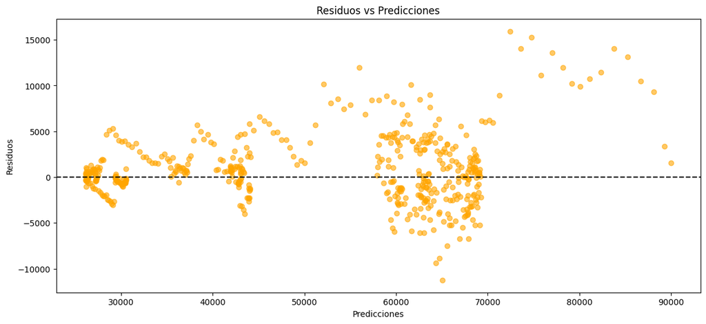

```python
residuals_vs_predictions(y_pred_list, residuos_b)
```

En la nube de puntos entre predicciones y residuos se puede observar que los errores que comete el modelo tienden a ser mayores conforme mayor es el precio, algo lógico en principio. Pero también se puede destacar que, a partir de los 70000 USDT todos los residuos son positivos, por lo que todos los errores cometidos son a la baja, es decir, estimando por debajo del valor real. Esto se traduce en que el modelo tiene ciertos problemas a la hora de estimar valores más altos del precio de BTC, si bien es cierto que, como se puede apreciar en el gráfico, no existen muchos datos de precios por encima de 70000 USDT, por lo que la recomendación sería reentrenar el modelo con nuevos datos más recientes, dado que en las últimas semanas BTC ha continuado por encima de 70000 USDT y no se dispone de dichos datos (recuérdese que se tienen datos hasta el 26 de noviembre de 2024). Este hecho puede ser explicado por ser los precios por encima de este valor mencionado una especie de territorio desconocido, no sólo para el modelo, sino también para el propio entorno de BTC.

También se observa que existen más residuos positivos que negativos, y que los primeros alcanzan mayores valores (hasta 15000) que los segundos (superan levemente los -10000).

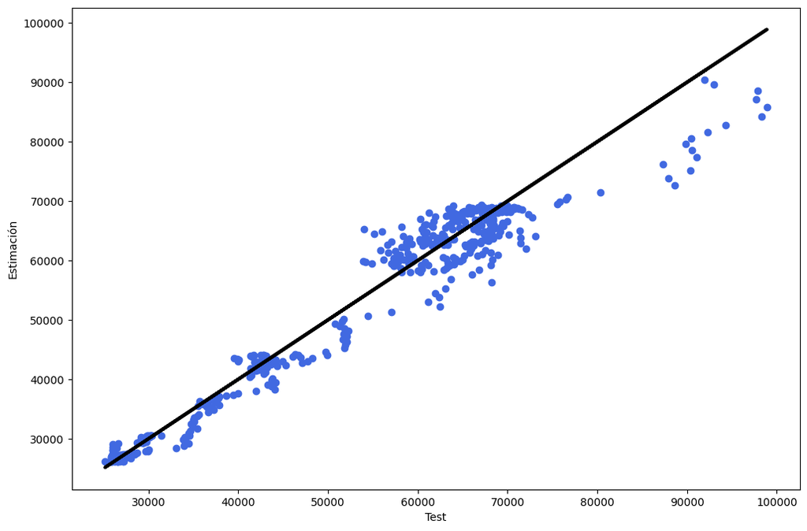

```python
test_vs_estimacion(y_test_list, y_pred_list_b)
```

Con la gráfica de confrontación de los datos reales de *test* y las predicciones se pueden constatar dos cosas:

- En primer lugar, que están bastante ajustadas a la recta, lo cual indica la gran precisión del modelo.
- En segundo lugar, se confirma tanto la mayor dispersión conforme aumenta el precio real del BTC como el hecho de que por encima de 70000 USDT las estimaciones están por debajo de los valores reales de *test* (puntos por debajo de la línea negra).

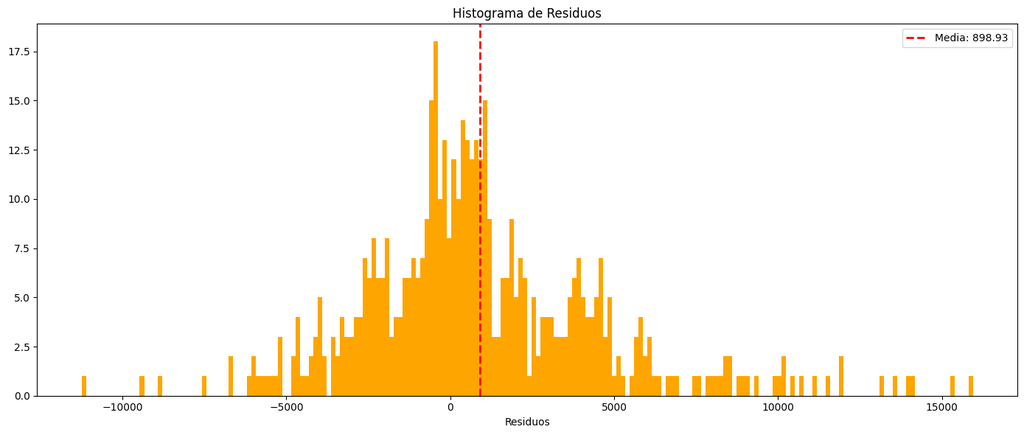

```python
residual_histogram(residuos_b, 200)
```

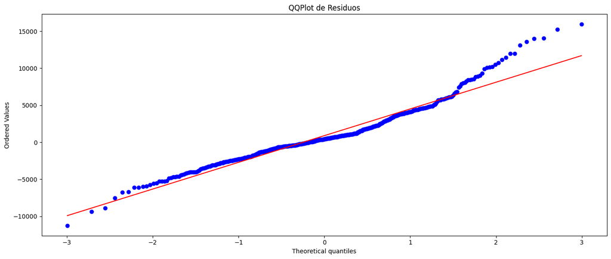

```python
residuals_qqplot(residuos_b)
```

Finalmente, el estudio de la normalidad de los residuos indica que éstos siguen una distribución normal aunque con un cierto sesgo a la derecha, también lógico dado que ya se ha constatado que existen más residuos positivos que negativos y que los primeros toman valores más extremos que los segundos. Aún así, tanto la distribución de los residuos como el gráfico QQ-PLOT indican una distribución bastante centrada en 0, aunque no exactamente 0.

**Conclusión:**

El modelo seleccionado, modelo B, es una red neuronal recurrente que ofrece unas predicciones bastante precisas y unas métricas que indican un gran ajuste tanto en validación como en *test*. También es cierto que no es un modelo exento de problemas, dado que se ha comprobado que los errores grandes penalizan con bastante fuerza y que cuando el precio es mayor y se tienen pocos datos, el modelo tiende a predecir a la baja.

### 6. Comparativa con modelos simples:

El objetivo final del estudio no es simplemente lograr un modelo funcional que sea capaz de predecir el precio de BTC sino la comparación de su desempeño con otros modelos considerados más simples que la red neuronal. Para ello, se seleccionarán cinco modelos que serán desarrollados y cuyas métricas serán comparadas con las obtenidas por la red neuronal recurrente. De esta comparativa se obtendrán las conclusiones acerca de la idoneidad o no del modelo seleccionado, permitiendo conocer si existen modelos más simples (y que, por tanto, requieren de menor capacidad computacional) capaces de obtener un desempeño similar al obtenido con la red neuronal.

*A priori*, y dado que el problema que se está tratando es bastante complejo, no parece sencillo que un modelo simple pueda capturar las relaciones complejas entre las variables, pero algunos de estos modelos podrían realizar un buen desempeño si son capaces de manejar bien la no linealidad de los datos.

```python
# Métricas del modelo Red Neuronal Recurrente
print(f"MÉTRICAS RED NEURONAL RECURRENTE:\n\
Coeficiente de Determinación (R2): {round(mean_r2_scores_b,4)}\n\
R2 en test: {round(r2_b,4)}\n\
R2 ajustado: {round(r2_adj_b,4)}\n\
MAE: {round(mae,2)}\n\
RMSE: {round(rmse,2)}\n\
Correlación entre datos de test y datos predichos: {round(correlation,4)}")
```

```
MÉTRICAS RED NEURONAL RECURRENTE:
Coeficiente de Determinación (R2): 0.9034
R2 en test: 0.9513
R2 ajustado: 0.9496
MAE: 2662.95
RMSE: 3790.88
Correlación entre datos de test y datos predichos: 0.9771
```

```python
# Se establecen nuevos conjuntos de entrenamiento y test para los modelos a comparar (_comp)
X_train_comp, y_train_comp = X[:train_size], y[:train_size]
X_test_comp, y_test_comp = X[train_size:], y[train_size:]
y_test_list_comp = np.array(df_close.close[train_size:].tolist())
```

#### 6.1. Regresión Lineal:

Podría considerarse como el modelo de regresión más simple, puesto que se centra exclusivamente en las relaciones lineales entre las características y el *target*. Como ya se conoce que el set de datos contiene relaciones más complejas que las relaciones lineales, es fácil anticipar que muy probablemente este modelo no obtendrá unos resultados muy buenos.

```python
lin_reg, r2_scores_lin_reg = linear_regression(X_train_comp, y_train_comp)
```

```
Fold: 1 - INICIO
Fold: 1 - R2: 0.9754
Fold: 2 - INICIO
Fold: 2 - R2: 0.9613
Fold: 3 - INICIO
Fold: 3 - R2: 0.99
Fold: 4 - INICIO
Fold: 4 - R2: 0.9886
Fold: 5 - INICIO
Fold: 5 - R2: 0.9834
```

```python
print("MÉTRICAS MODELO DE REGRESIÓN LINEAL:")
mean_r2_scores_lin_reg = np.mean(r2_scores_lin_reg)
print(f"Coeficiente de Determinación (R2): {round(mean_r2_scores_lin_reg,4)}")  # R2 en validación

y_test_pred_lin_reg = lin_reg.predict(X_test_comp)

y_pred_lin_reg = []
for i, pred in enumerate(y_test_pred_lin_reg):
    denorm = denormalize_data(_data=pred, _df=df_close, _index=denorm_index + i)
    y_pred_lin_reg.append(denorm)

y_pred_list_lin_reg = np.array(y_pred_lin_reg)

residuos_lin_reg = y_test_list_comp[:-1] - y_pred_list_lin_reg[:-1]

r2_lin_reg = r2_score(y_test_list_comp[:-1], y_pred_list_lin_reg[:-1])
print(f"R2 en test: {round(r2_lin_reg, 4)}")

r2_adj_lin_reg = round(adjusted_r2(r2_lin_reg, n, p),4)
print(f"R2 ajustado: {round(r2_adj_lin_reg, 4)}")

mae_lin_reg = mean_absolute_error(y_test_list_comp[:-1], y_pred_list_lin_reg[:-1])
print(f"MAE: {round(mae_lin_reg, 2)}")

mse_lin_reg = mean_squared_error(y_test_list_comp[:-1], y_pred_list_lin_reg[:-1])
rmse_lin_reg = np.sqrt(mse_lin_reg)
print(f"RMSE: {round(rmse_lin_reg, 2)}")

correlation_lin_reg = np.corrcoef(y_test_list_comp[:-1], y_pred_list_lin_reg[:-1])[0, 1]
print(f"Correlación entre datos de test y datos predichos: {round(correlation_lin_reg, 4)}")
```

```
MÉTRICAS MODELO DE REGRESIÓN LINEAL:
Coeficiente de Determinación (R2): 0.9798
R2 en test: 0.8784
R2 ajustado: 0.8741
MAE: 3910.12
RMSE: 6028.48
Correlación entre datos de test y datos predichos: 0.9554
```

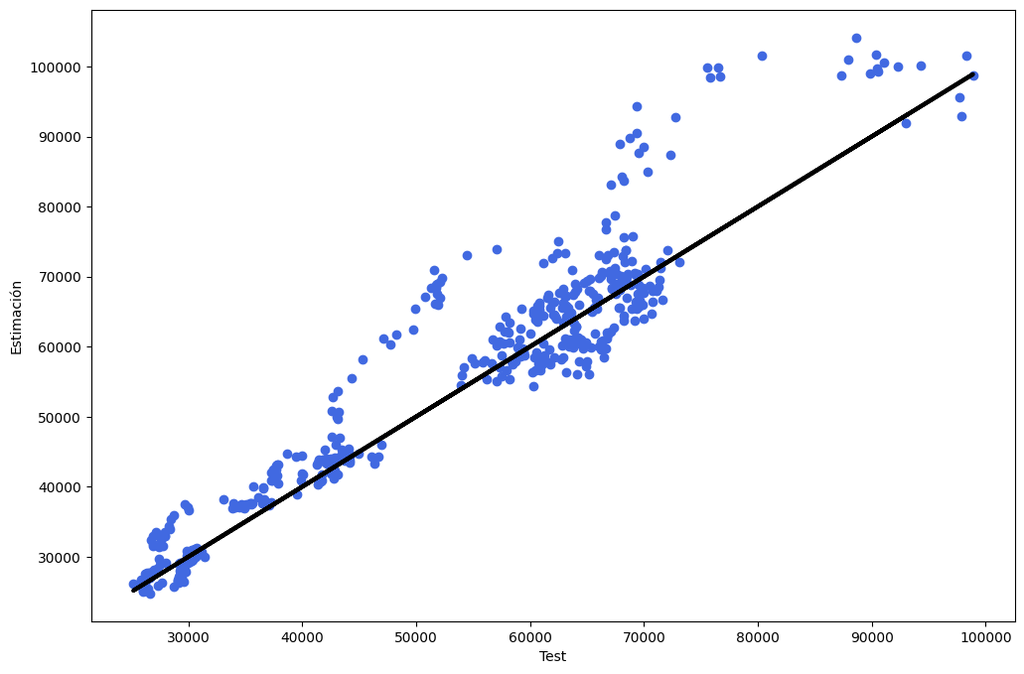

```python
test_vs_estimacion(y_test_list_comp[:-1], y_pred_list_lin_reg[:-1])
```

En la comparación entre las métricas de ambos modelos, se puede confirmar que, aunque el modelo de regresión lineal se comporta bastante mejor de lo esperado, la red neuronal recurrente tiene una mayor precisión a la hora de predecir el precio como demuestran un mayor R2 en *test* y unos menores errores medios tanto en términos absolutos como cuadráticos. Cabe destacar que el modelo de regresión lineal, a pesar de ser el más simple, consigue explicar la variabilidad de casi el 100% de los datos del precio de BTC y la correlación entre los datos predichos y los datos reales es superior a 0.95.

En el gráfico comparativo de valores de *test* frente a valores de las predicciones se pone de manifiesto una tendencia a sobreestimar los valores reales durante el *test*.

#### 6.2. Random Forest:

El modelo Random Forest ofrece una gran robustez y maneja bien la no linealidad, permitiendo al mismo tiempo trabajar con datos de series temporales si se emplean ventanas temporales, aunque tiene la desventaja de no poder capturar directamente la estructura temporal como hacen los modelos recurrentes.

```python
params_rand_for = {
        "n_estimators" : 100,
        "max_depth" : 10,
        "random_state" : 42,
        "n_jobs" : -1
}

rand_for, r2_scores_rand_for = random_forest(X_train_array_shape, y_train_array_shape, params_rand_for)
```

```
Fold: 1 - INICIO
Fold: 1 - R2: 0.9947
Fold: 2 - INICIO
Fold: 2 - R2: 0.9809
Fold: 3 - INICIO
Fold: 3 - R2: 0.9975
Fold: 4 - INICIO
Fold: 4 - R2: 0.9926
Fold: 5 - INICIO
Fold: 5 - R2: 0.9932
```

```python
print("MÉTRICAS MODELO RANDOM FOREST:")
mean_r2_scores_rand_for = np.mean(r2_scores_rand_for)
print(f"Coeficiente de Determinación (R2): {round(mean_r2_scores_rand_for,4)}")  # R2 en validación

y_test_pred_rand_for = rand_for.predict(X_test_array_shape.reshape(X_test_array_shape.shape[0], -1))

y_pred_rand_for = []
for i, pred in enumerate(y_test_pred_rand_for):
    denorm = denormalize_data(_data=pred, _df=df_close, _index=denorm_index + i)
    y_pred_rand_for.append(denorm)

y_pred_list_rand_for = np.array(y_pred_rand_for)

residuos_rand_for = y_test_list - y_pred_list_rand_for

r2_rand_for = r2_score(y_test_list, y_pred_list_rand_for)
print(f"R2 en test: {round(r2_rand_for, 4)}")

r2_adj_rand_for = round(adjusted_r2(r2_rand_for, n, p),4)
print(f"R2 ajustado: {round(r2_adj_rand_for, 4)}")

mae_rand_for = mean_absolute_error(y_test_list, y_pred_list_rand_for)
print(f"MAE: {round(mae_rand_for, 2)}")

mse_rand_for = mean_squared_error(y_test_list, y_pred_list_rand_for)
rmse_rand_for = np.sqrt(mse_rand_for)
print(f"RMSE: {round(rmse_rand_for, 2)}")

correlation_rand_for = np.corrcoef(y_test_list, y_pred_list_rand_for)[0, 1]
print(f"Correlación entre datos de test y datos predichos: {round(correlation_rand_for, 4)}")
```

```
MÉTRICAS MODELO RANDOM FOREST:
Coeficiente de Determinación (R2): 0.9918
R2 en test: 0.9328
R2 ajustado: 0.9304
MAE: 3115.91
RMSE: 4456.05
Correlación entre datos de test y datos predichos: 0.9665
```

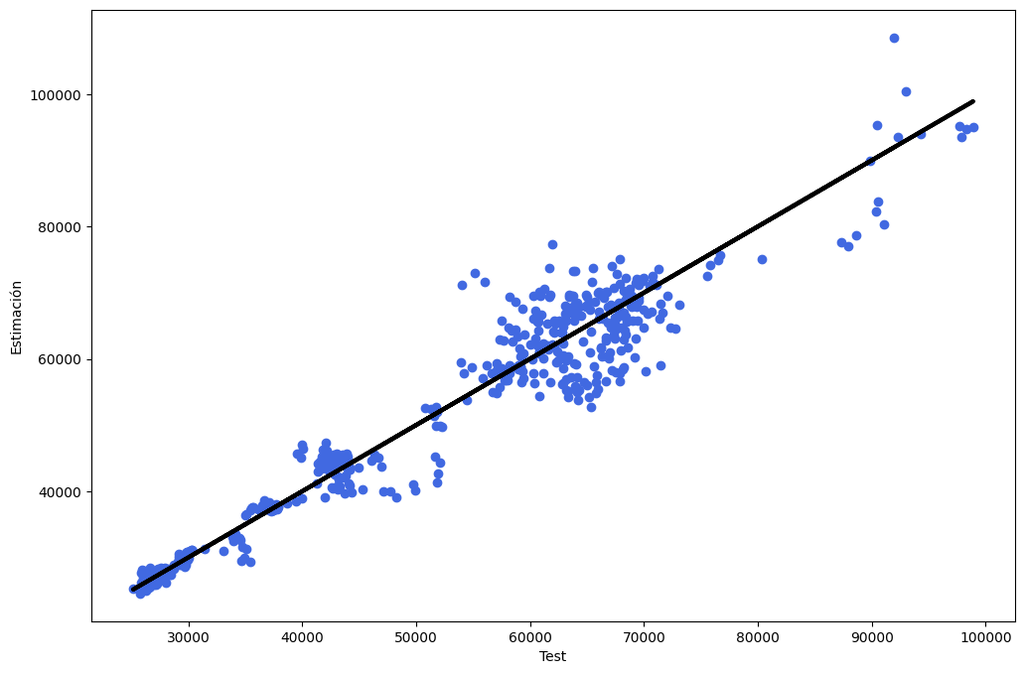

```python
test_vs_estimacion(y_test_list, y_pred_list_rand_for)
```

En este caso, random forest destaca por su aprendizaje casi perfecto en los conjuntos de validación, con un R2 cercano a 1, pero su métrica en *test* es algo inferior a la obtenida por la red neuronal, lo que sugiere que podría estar ligeramente sobreajustado a los datos de entrenamiento. Si se decide reentrenar este modelo tratando de mejorar su desempeño en *test*, una opción podría ser reajustar los hiperparámetros, por ejemplo reduciendo la profundidad máxima (_max*depth*), lo que podría ayudar a reducir el sobreajuste.

Los errores medios cometidos en las predicciones por random forest son algo superiores a los de la red neuronal, y ésta última tiene una correlación entre los datos de *test* y las predicciones ligeramente superior.

En conclusión, random forest tiene un desempeño excelente en validación pero pierde generalización en el conjunto de prueba, por lo que, en términos de generalización y estabilidad en *test*, la red neuronal sigue siendo mejor opción.

#### 6.3. Gradient Boosting Regressor:

*A priori*, supone una mejor alternativa que el Random Forest, ya que es capaz de capturar relaciones complejas, es eficiente y suele dar buen desempeño con datos estructurados. Es posible que sea necesario el ajuste de los hiperparámetros hasta encontrar el mejor rendimiento, siendo XGBoost la opción elegida.

```python
params_xgb = {
        "n_estimators" : 100,
        "learning_rate" : 0.1,
        "max_depth" : 6,
        "subsample" : 0.8,
        "colsample_bytree" : 0.8,
        "random_state" : 42
}

xgb_model, r2_scores_xgb = xgboost(X_train_array_shape, y_train_array_shape, params_xgb)
```

```
Fold: 1 - INICIO
Fold: 1 - R2: 0.9955
Fold: 2 - INICIO
Fold: 2 - R2: 0.984
Fold: 3 - INICIO
Fold: 3 - R2: 0.9982
Fold: 4 - INICIO
Fold: 4 - R2: 0.9947
Fold: 5 - INICIO
Fold: 5 - R2: 0.9948
```

```python
print("MÉTRICAS MODELO XGBOOST:")
mean_r2_scores_xgb = np.mean(r2_scores_xgb)
print(f"Coeficiente de Determinación (R2): {round(mean_r2_scores_xgb,4)}")

y_test_pred_xgb = xgb_model.predict(X_test_array_shape.reshape(X_test_array_shape.shape[0], -1))

y_pred_xgb = []
for i, pred in enumerate(y_test_pred_xgb):
    denorm = denormalize_data(_data=pred, _df=df_close, _index=denorm_index + i)
    y_pred_xgb.append(denorm)

y_pred_list_xgb = np.array(y_pred_xgb)

residuos_xgb = y_test_list - y_pred_list_xgb

r2_xgb = r2_score(y_test_list, y_pred_list_xgb)
print(f"R2 en test: {round(r2_xgb, 4)}")

r2_adj_xgb = round(adjusted_r2(r2_xgb, n, p),4)
print(f"R2 ajustado: {round(r2_adj_xgb, 4)}")

mae_xgb = mean_absolute_error(y_test_list, y_pred_list_xgb)
print(f"MAE: {round(mae_xgb, 2)}")

mse_xgb = mean_squared_error(y_test_list, y_pred_list_xgb)
rmse_xgb = np.sqrt(mse_xgb)
print(f"RMSE: {round(rmse_xgb, 2)}")

correlation_xgb = np.corrcoef(y_test_list, y_pred_list_xgb)[0, 1]
print(f"Correlación entre datos de test y datos predichos: {round(correlation_xgb, 4)}")
```

```
MÉTRICAS MODELO XGBOOST:
Coeficiente de Determinación (R2): 0.9934
R2 en test: 0.933
R2 ajustado: 0.9306
MAE: 3120.33
RMSE: 4448.46
Correlación entre datos de test y datos predichos: 0.9666
```

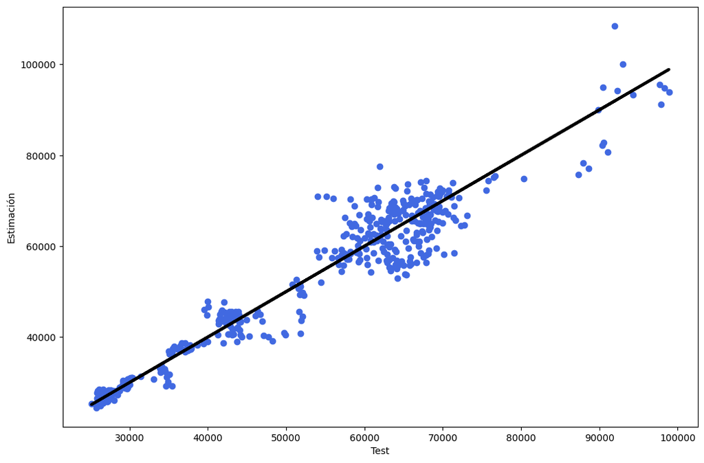

```python
test_vs_estimacion(y_test_list, y_pred_list_xgb)
```

Las métricas obtenidas por el modelo XGBoost son prácticamente idénticas a las obtenidas por random forest, lo que sugiere que ambos modelos logran capturar de manera efectiva las relaciones no lineales en los datos. Esto probablemente se deba a que ambos modelos se basan en la construcción de conjuntos de árboles de decisión, aunque con diferente enfoque.

Aunque XGBoost es un modelo que mejora su eficiencia en conjuntos de datos más grandes, puede ser más robusto que random forest en escenarios con ruido, como en este caso, donde no se han eliminado valores *outliers*. Esta robustez frente a los ruidos la obtiene de mecanismos como la regularización L1 y L2; en este caso, dado que no se han especificado valores para *alpha* y *lambda*, XGBoost ha aplicado un *lambda* = 1 por defecto, lo que implica que ha realizado una regularización de Ridge (L2) con dicho valor.

#### 6.4. AutoRegressive Integrated Moving Average (ARIMA):

Es un modelo diseñado específicamente para series temporales que maneja patrones de autocorrelación y estacionalidad, por lo que podría ser una buena alternativa al complejo modelo de la red neuronal. También hay que destacar que es limitado en cuanto a la capacidad para manejar datos con relaciones no lineales o con múltiples características.

```python
auto_model = auto_arima(
    y_train,
    seasonal=False,
    stepwise=True,
    trace=True,  # Muestra detalles de la búsqueda
    suppress_warnings=True,
    error_action="ignore",
    max_order=None,  # Deja la búsqueda libre de restricciones
)

# Mejor modelo encontrado
best_p, best_d, best_q = auto_model.order

params_arima = {
    "p" : best_p,
    "d" : best_d,
    "q" : best_q
}

print(f"Mejores parámetros encontrados: p={best_p}, d={best_d}, q={best_q}")
```

```
Performing stepwise search to minimize aic
 ARIMA(2,0,2)(0,0,0)[0]             : AIC=4109.720, Time=4.61 sec
 ARIMA(0,0,0)(0,0,0)[0]             : AIC=7254.595, Time=0.02 sec
 ARIMA(1,0,0)(0,0,0)[0]             : AIC=4105.492, Time=0.10 sec
 ARIMA(0,0,1)(0,0,0)[0]             : AIC=5632.347, Time=0.61 sec
 ARIMA(2,0,0)(0,0,0)[0]             : AIC=4107.491, Time=0.84 sec
 ARIMA(1,0,1)(0,0,0)[0]             : AIC=4107.491, Time=0.71 sec
 ARIMA(2,0,1)(0,0,0)[0]             : AIC=4109.492, Time=1.44 sec
 ARIMA(1,0,0)(0,0,0)[0] intercept   : AIC=4106.104, Time=0.21 sec

Best model:  ARIMA(1,0,0)(0,0,0)[0]
Total fit time: 8.547 seconds
Mejores parámetros encontrados: p=1, d=0, q=0
```

```python
arima_model, r2_scores_arima = arima(df_close.close[:train_size], params_arima)
```

```
Fold: 1 - INICIO
Fold: 1 - R2: -0.4495
Fold: 2 - INICIO
Fold: 2 - R2: -0.2982
Fold: 3 - INICIO
Fold: 3 - R2: -1.9898
Fold: 4 - INICIO
Fold: 4 - R2: -1.5904
Fold: 5 - INICIO
Fold: 5 - R2: -0.1814
```

```python
print("MÉTRICAS MODELO ARIMA:")
mean_r2_scores_arima = np.mean(r2_scores_arima)
print(f"Coeficiente de Determinación (R2): {round(mean_r2_scores_arima,4)}")

y_test_arima = df_close.close[train_size:]
start_arima = len(y_train)
end_arima = len(y_train) + len(y_test) - 1

y_pred_arima = arima_model.predict(start_arima, end_arima)

residuos_arima = y_test_arima - y_pred_arima

r2_arima = r2_score(y_test_arima, y_pred_arima)
print(f"R2 en test: {round(r2_arima, 4)}")

r2_adj_arima = round(adjusted_r2(r2_arima, n, p),4)
print(f"R2 ajustado: {round(r2_adj_arima, 4)}")

mae_arima = mean_absolute_error(y_test_arima, y_pred_arima)
print(f"MAE: {round(mae_arima, 2)}")

mse_arima = mean_squared_error(y_test_arima, y_pred_arima)
rmse_arima = np.sqrt(mse_arima)
print(f"RMSE: {round(rmse_arima, 2)}")

correlation_arima = np.corrcoef(y_test_arima, y_pred_arima)[0, 1]
print(f"Correlación entre datos de test y datos predichos: {round(correlation_arima, 4)}")
```

```
MÉTRICAS MODELO ARIMA:
Coeficiente de Determinación (R2): -0.9019
R2 en test: -3.2096
R2 ajustado: -3.3569
MAE: 31014.44
RMSE: 35619.06
Correlación entre datos de test y datos predichos: -0.8968
```

Con unos coeficientes de determinación negativos tanto en entrenamiento como en *test*, se puede afirmar que el modelo ARIMA tiene un desempeño incluso inferior a un modelo de referencia que prediga constantemente la media de los datos del conjunto de entrenamiento. Por lo tanto, este modelo es incapaz de capturar las tendencias y patrones de los datos.

Tanto MAE como RMSE son relativamente altos, algo de esperar en un modelo con tan pobre desempeño. Por otro lado, la correlación negativa, bastante cercana a -1, indica que el modelo no sólo falla a la hora de capturar los patrones, sino que además sus predicciones se mueven en dirección opuesta a la tendencia de los datos.

Entre los motivos por los que este modelo podría estar teniendo un mal desempeño se encuentran la posible inadecuación del modelo para capturar correctamente los patrones subyacentes en una serie temporal de datos complejos como es el precio de un activo financiero, la posible selección errónea de los hiperparámetros encontrados por _auto*arima* y la alta volatilidad y el ruido provocado por los *outliers* no eliminados durante la fase de preparación de los datos.

#### 6.5. Support Vector Regressor (SVR):

Es un modelo flexible para problemas de regresión y puede capturar patrones no lineales usando un kernel no lineal como RBF, si bien su escalabilidad es limitada para grandes conjuntos de datos.

```python
params_svr = {
    "kernel": "rbf",
    "C": 1.0,         # Regularización; 1 por defecto
    "epsilon": 0.1    # Margen de tolerancia para errores
}
```

```python
svr_model, r2_scores_svr = svr(X_train_array_shape, y_train_array_shape, params_svr, _n_splits=2)
```

```
Fold: 1 - INICIO
Fold: 1 - R2: 0.9659
Fold: 2 - INICIO
Fold: 2 - R2: 0.9434
```

```python
print("MÉTRICAS MODELO SVR:")
mean_r2_scores_svr = np.mean(r2_scores_svr)
print(f"Coeficiente de Determinación (R2): {round(mean_r2_scores_svr,4)}")

y_test_pred_svr = svr_model.predict(X_test_array_shape.reshape(X_test_array_shape.shape[0], -1))

y_pred_svr = []
for i, pred in enumerate(y_test_pred_svr):
    denorm = denormalize_data(_data=pred, _df=df_close, _index=denorm_index + i)
    y_pred_svr.append(denorm)

y_pred_list_svr = np.array(y_pred_svr)

residuos_svr = y_test_list - y_pred_list_svr

r2_svr = r2_score(y_test_list, y_pred_list_svr)
print(f"R2 en test: {round(r2_svr, 4)}")

r2_adj_svr = round(adjusted_r2(r2_svr, n, p),4)
print(f"R2 ajustado: {round(r2_adj_svr, 4)}")

mae_svr = mean_absolute_error(y_test_list, y_pred_list_svr)
print(f"MAE: {round(mae_svr, 2)}")

mse_svr = mean_squared_error(y_test_list, y_pred_list_svr)
rmse_svr = np.sqrt(mse_svr)
print(f"RMSE: {round(rmse_svr, 2)}")

correlation_svr = np.corrcoef(y_test_list, y_pred_list_svr)[0, 1]
print(f"Correlación entre datos de test y datos predichos: {round(correlation_svr, 4)}")
```

```
MÉTRICAS MODELO SVR:
Coeficiente de Determinación (R2): 0.9546
R2 en test: 0.979
R2 ajustado: 0.9782
MAE: 1707.85
RMSE: 2491.3
Correlación entre datos de test y datos predichos: 0.9907
```

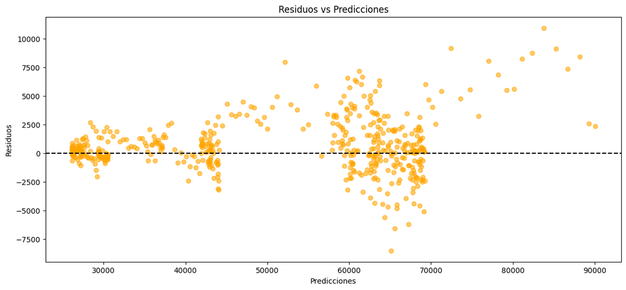

```python
residuals_vs_predictions(y_pred_list, residuos_svr)
```

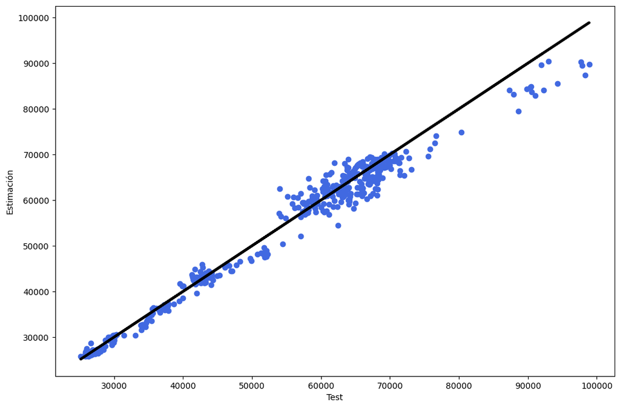

```python
test_vs_estimacion(y_test_list, y_pred_list_svr)
```

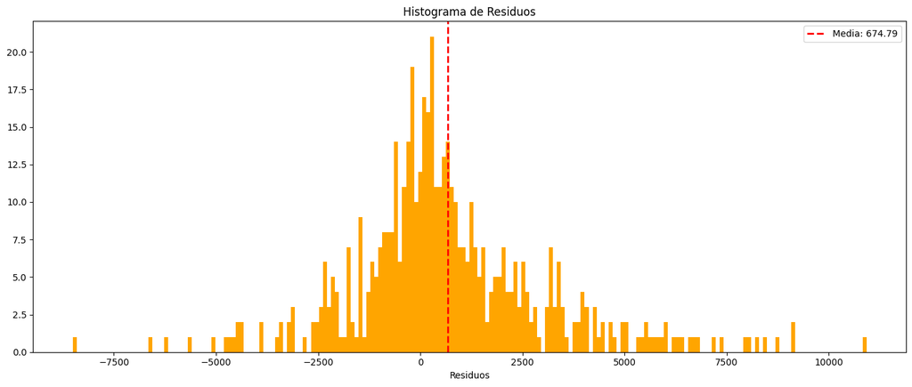

```python
residual_histogram(residuos_svr, 200)
```

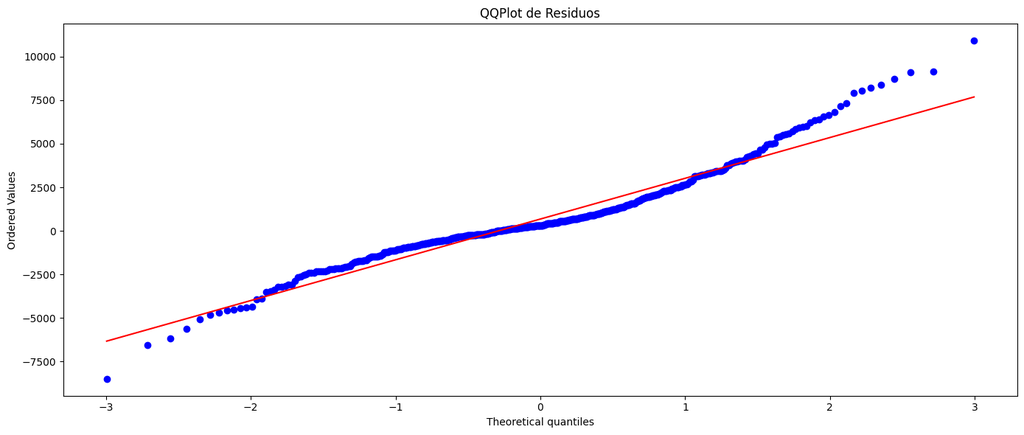

```python
residuals_qqplot(residuos_svr)
```

En general, el modelo SVR muestra unos mejores resutados en cuanto a las métricas básicas que la red neuronal:

- Coeficientes de determinación superiores tanto en entrenamiento como en *test*, lo que indica un mejor ajuste y capacidad de generalización.
- MAE y RMSE inferiores, indicando errores medios absoluto y cuadrático menores, es decir, mayor precisión de las predicciones.
- Una mejor correlación de los datos de *test* con las predicciones, lo que refuerza la capacidad del modelo para capturar patrones significativos.

En el estudio gráfico de los residuos también se puede ver esta mejora, observándose un mayor ajuste de las estimaciones a la recta de *test*, un histograma de residuos con menor dispersión y media más cercana a 0, y un mejor ajuste de los valores a la recta del gráfico QQPlot, lo que indica que, efectivamente, los residuos siguen una distribución aproximadamente normal.

Aunque las redes neuronales recurrentes suelen ser las más adecuadas para capturar patrones temporales complejos en series temporales debido a su capacidad de modelar relaciones a largo plazo, en este caso no ha sido capaz de superar al modelo SVR.

A pesar de la normalización z-score de los datos para disminuir la influencia de los valores *outliers* en el entrenamiento de la red neuronal recurrente, parece que la regularización del modelo SVR mediante el parámetro de regularización *C* ayuda a ajustar mejor este modelo de lo que lo hace la red neuronal.

Además, las redes neuronales recurrentes suelen requerir datasets grandes para entrenar modelos robustos, mientras SVR no, por lo que se puede intuir que quizá los patrones en el precio de BTC no se mantengan tan a largo plazo sino que cambian en el medio o corto plazo, es decir, son más estáticos, por lo que tendría sentido que SVR pudiera conseguir un mejor aprendizaje de estos patrones que la red neuronal.

#### 6.6. CONCLUSIÓN

Tabla de métricas para la comparativa de los modelos:

```python
metric_summary_data = {
    "MODELO": ["Red Neuronal Recurrente", "Regresión lineal", "Random Forest", "XGBoost", "ARIMA", "SVR"],
    "R2": [round(mean_r2_scores_b,4), round(mean_r2_scores_lin_reg,4), round(mean_r2_scores_rand_for,4),
           round(mean_r2_scores_xgb,4), round(mean_r2_scores_arima,4), round(mean_r2_scores_svr,4)],
    "R2 en test": [round(r2_b,4), round(r2_lin_reg,4), round(r2_rand_for,4), round(r2_xgb,4),
                   round(r2_arima,4), round(r2_svr,4)],
    "R2 ajustado" : [round(r2_adj_b,4), round(r2_adj_lin_reg,4), round(r2_adj_rand_for,4), round(r2_adj_xgb,4),
                     round(r2_adj_arima,4), round(r2_adj_svr,4)],
    "MAE" : [round(mae,2), round(mae_lin_reg,2), round(mae_rand_for,2), round(mae_xgb,2),
             round(mae_arima,2), round(mae_svr,2)],
    "RMSE" : [round(rmse,2), round(rmse_lin_reg,2), round(rmse_rand_for,2), round(rmse_xgb,2),
              round(rmse_arima,2), round(rmse_svr,2)],
    "Correlación test/predicción": [round(correlation,4), round(correlation_lin_reg,4), round(correlation_rand_for,4),
                                    round(correlation_xgb,4), round(correlation_arima,4), round(correlation_svr,4)]
}

metric_summary = pd.DataFrame(metric_summary_data)
metric_summary
```

|  | MODELO | R2 | R2 en test | R2 ajustado | MAE | RMSE | Correlación test/predicción |
| --- | --- | --- | --- | --- | --- | --- | --- |
| 0 | Red Neuronal Recurrente | 0.9034 | 0.9513 | 0.9496 | 2662.95 | 3790.88 | 0.9771 |
| 1 | Regresión lineal | 0.9798 | 0.8784 | 0.8741 | 3910.12 | 6028.48 | 0.9554 |
| 2 | Random Forest | 0.9918 | 0.9328 | 0.9304 | 3115.91 | 4456.05 | 0.9665 |
| 3 | XGBoost | 0.9934 | 0.9330 | 0.9306 | 3120.33 | 4448.46 | 0.9666 |
| 4 | ARIMA | -0.9019 | -3.2096 | -3.3569 | 31014.44 | 35619.06 | -0.8968 |
| 5 | SVR | 0.9546 | 0.9790 | 0.9782 | 1707.85 | 2491.30 | 0.9907 |

Tras el entrenamiento de los modelos predictivos y el análisis de sus métricas básicas se pueden obtener las siguientes conclusiones:

- La **red neuronal recurrente**, el modelo que originalmente se pensó podía ser el más adecuado para un proyecto de la complejidad del problema tratado, ha demostrado un desempeño muy óptimo, con unos coeficientes de determinación tanto en entrenamiento como en *test* bastante buenos (por encima de 0.9 y 0.95 respectivamente), unos errores medio absoluto y cuadrático medio bastante bajos y una correlación entre datos de *test* y predicciones muy próximo a 1.
- Los modelos de **regresión lineal**, **random forest** y **XGBoost** obtienen también unos resultados bastante buenos, superando a la red neuronal en el ajuste del modelo a los datos de entrenamiento, aunque no siendo capaz de generalizar tan bien como ésta (R2 en *test* altos pero inferiores al de la red neuronal, e inferiores a sus respectivos R2 en validación, lo que señala posibles problemas de sobreajuste). Por otro lado, a pesar de sus buenos desempeños, todos ellos cometen errores en sus predicciones mayores que los que comete la red neuronal, como indican unas MAE y RMSE superiores y una correlación entre datos de *test* y predicciones algo inferiores.
- El modelo **ARIMA**, basado en la búsqueda de patrones de autocorrelación entre los datos de la propia variable *target* (en este caso, el precio de BTC) sin considerar otras variables, ha resultado ser un modelo totalmente inadecuado para este problema, dado que obtiene R2 negativos, errores muy elevados y correlación *test*/predicción cercana a -1.
- El modelo **support vector regressor** ha conseguido superar a la red neuronal en todas las métricas, ajustando mejor el modelo a los datos de entrenamiento, generalizando mejor, cometiendo menores errores y logrando una correlación de datos de *test* y predicciones casi 1.

Por lo tanto, después del estudio de todos estos modelos, la conclusión final es que la **red neuronal recurrente** ha demostrado ser un modelo bastante óptimo y adecuado para la predicción del precio de BTC, con un desempeño sólido y una gran capacidad de generalización, si bien existen alternativas, como la demostrada con **SVR**, que obtienen mejores resultados y requieren de una menor capacidad computacional y tiempo para el entrenamiento y la predicción.

### 7. Despliegue del modelo

Aunque este proyecto tiene un propósito de investigación y no contempla un despliegue real del modelo, a continuación, se enumeran una serie de recomendaciones clave para implementar el modelo en un entorno productivo, como por ejemplo una aplicación de inversiones financieras:

- **Definición de un entorno de producción**: la selección de una infraestructura adecuada para alojar y ejecutar el modelo es vital, siendo las opciones en la nube, como AWS de Amazon, GCP de Google o Azure de Microsoft, las más adecuadas si se pretende mantener activo el modelo 24 horas y que sea accesible por una gran cantidad de clientes simultáneamente. Será necesario asegurarse de que el entorno incluya todas las dependencias necesarias como las bibliotecas de Python o *frameworks* como Scikit_Learn y TensorFlow, así como configurar contenedores mediante tecnologías como Docker para garantizar reproducibilidad y escalabilidad.
- **Automatización del flujo de trabajo**: implementar *pipelines* de *machine learning* que automaticen la ingesta de nuevos datos y el preprocesamiento, así como gestionar los flujos de trabajo y el seguimiento de las métricas del modelo.
- **Monitorización del modelo**: establecer mecanismos de monitorización para evaluar el rendimiento del modelo en producción y detectar posibles degradaciones debido al *data drifting* e integrar métricas como R2, MAE y RMSE para realizar un seguimiento continuo de las predicciones.
- **Mantenimiento del modelo**: diseñar estrategias para reentrenar el modelo de manera constante.
- **Otras acciones**: realizar otras acciones subsidiarias, como implementación de mecanismos de seguridad de los datos, implementación de soluciones que permitan la escalabilidad, o realización de una documentación técnica para el equipo de desarrollo y otra para los usuarios finales.

Finalmente, es importante recordar que este modelo, como cualquier otro modelo predictivo, debe ser utilizado como una herramienta de apoyo y no como reemplazo de la toma de decisiones por parte de los usuarios, dada la naturaleza volátil de un activo financiero como es BTC. Además, es fundamental comunicar las limitaciones y riesgos asociados al uso del modelo para evitar expectativas irreales sobre su rendimiento.